# Iris Data Set

Eric Leung

July 28th, 2015

# Introduction

The Iris Data Set was downloaded from the [UCI Machine Learning Repository](http://archive.ics.uci.edu/ml/datasets/Iris).

“This is perhaps the best known database to be found in the pattern recognition literature. Fisher’s paper is a classic in the field and is referenced frequently to this day. (See Duda & Hart, for example.) The data set contains 3 classes of 50 instances each, where each class refers to a type of iris plant. One class is linearly separable from the other 2; the latter are NOT linearly separable from each other.”

## Attribute Information

1. sepal length in cm
2. sepal width in cm
3. petal length in cm
4. petal width in cm
5. class:
   - Iris Setosa
   - Iris Versicolour
   - Iris Virginica

# Goal

The iris data set contains four potential predictive values: sepal length, sepal width, petal length, and petal width. One or more combinations of these attributes may be used to predict the iris class, which can be one of three classes: Setosa, Versicolour, or virginica.

Before we can predict on the data, we will perform an exploratory data analysis to understand nuances in the data.

# Load Packages

```r
require(ggplot2)
require(dplyr)
require(GGally)
```

# Load Data

```r
dat <- read.csv(file = "../data/iris.data")

# name columns based on attributes above
names(dat) <- c(
    "sepal.length", "sepal.width",
    "petal.length", "petal.width",
    "class")

dat <- tbl_df(dat)
dat
```

```
## Source: local data frame [149 x 5]
##
##    sepal.length sepal.width petal.length petal.width       class
##           (dbl)       (dbl)        (dbl)       (dbl)      (fctr)
## 1           4.9         3.0          1.4         0.2 Iris-setosa
## 2           4.7         3.2          1.3         0.2 Iris-setosa
## 3           4.6         3.1          1.5         0.2 Iris-setosa
## 4           5.0         3.6          1.4         0.2 Iris-setosa
## 5           5.4         3.9          1.7         0.4 Iris-setosa
## 6           4.6         3.4          1.4         0.3 Iris-setosa
## 7           5.0         3.4          1.5         0.2 Iris-setosa
## 8           4.4         2.9          1.4         0.2 Iris-setosa
## 9           4.9         3.1          1.5         0.1 Iris-setosa
## 10          5.4         3.7          1.5         0.2 Iris-setosa
## ..          ...         ...          ...         ...         ...
```

# Explore Data

```r
str(dat) # take a look at data and kinds of data
```

```
## Classes 'tbl_df', 'tbl' and 'data.frame':    149 obs. of  5 variables:
##  $ sepal.length: num  4.9 4.7 4.6 5 5.4 4.6 5 4.4 4.9 5.4 ...
##  $ sepal.width : num  3 3.2 3.1 3.6 3.9 3.4 3.4 2.9 3.1 3.7 ...
##  $ petal.length: num  1.4 1.3 1.5 1.4 1.7 1.4 1.5 1.4 1.5 1.5 ...
##  $ petal.width : num  0.2 0.2 0.2 0.2 0.4 0.3 0.2 0.2 0.1 0.2 ...
##  $ class       : Factor w/ 3 levels "Iris-setosa",..: 1 1 1 1 1 1 1 1 1 1 ...
```

There appears to be 149 samples with 5 different variables. Four out of the five appear have numerical data types while the last variable is a factor variable. This factor variable is what we will predict on, which is the class of the flower.

```r
summary(dat) # look at some summary statistics of data
```

```
##   sepal.length    sepal.width     petal.length    petal.width
##  Min.   :4.300   Min.   :2.000   Min.   :1.000   Min.   :0.100
##  1st Qu.:5.100   1st Qu.:2.800   1st Qu.:1.600   1st Qu.:0.300
##  Median :5.800   Median :3.000   Median :4.400   Median :1.300
##  Mean   :5.848   Mean   :3.051   Mean   :3.774   Mean   :1.205
##  3rd Qu.:6.400   3rd Qu.:3.300   3rd Qu.:5.100   3rd Qu.:1.800
##  Max.   :7.900   Max.   :4.400   Max.   :6.900   Max.   :2.500
##              class
##  Iris-setosa    :49
##  Iris-versicolor:50
##  Iris-virginica :50
##
##
##
```

```r
dat %>% select(-contains("class")) %>%
    apply(MARGIN = 2, FUN = sd) # look at standard deviation of data
```

```
## sepal.length  sepal.width petal.length  petal.width
##    0.8285941    0.4334989    1.7596512    0.7612920
```

```r
dat %>% select(-contains("class")) %>%
    apply(MARGIN = 2, FUN = range) # look at range of values vars can take
```

```
##      sepal.length sepal.width petal.length petal.width
## [1,]          4.3         2.0          1.0         0.1
## [2,]          7.9         4.4          6.9         2.5
```

These summary statistics give us a brief overview of how the data looks like. Each of the different variables do not appear to vary much in range. Petal length appears to have the greatest standard deviation and widest range. Additionally, each class of iris are almost equal in frequency. It is also worth noting there doesn’t appear to be any missing values in terms of class.

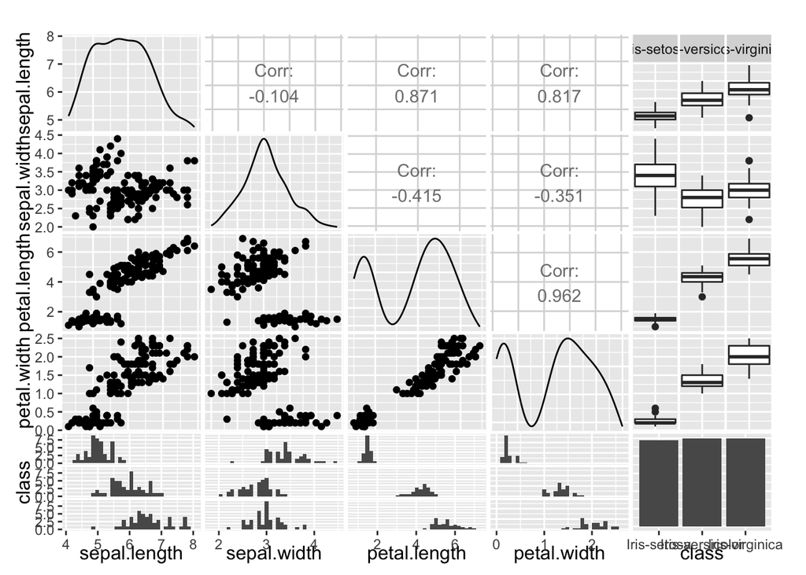

```r
ggpairs(dat) # look at all pairwise plots of variables
```

Here we can look at big picture trends. From here, we might be able to make the following claims:

- Sepal length appears to be a good distinguisher among the three iris classes as their box plots do not overlap very much, if any. However, looking at a different view of the boxplots in terms of histograms, we can see the amount of overlap among the flowers.
- Petal length and petal width are another variable that might be helpful in distinguishing among the different classes. Both of their histograms show that one class of iris, setosa, can be uniquely identified using these two variables.

## Explore Sepal Properties

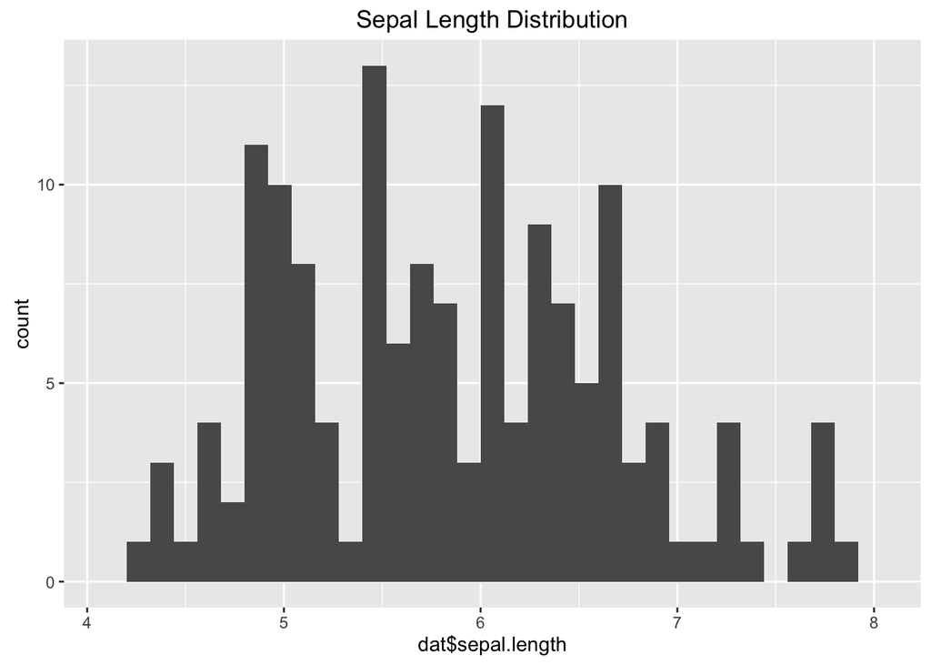

```r
qplot(x = dat$sepal.length,
      main = "Sepal Length Distribution")
```

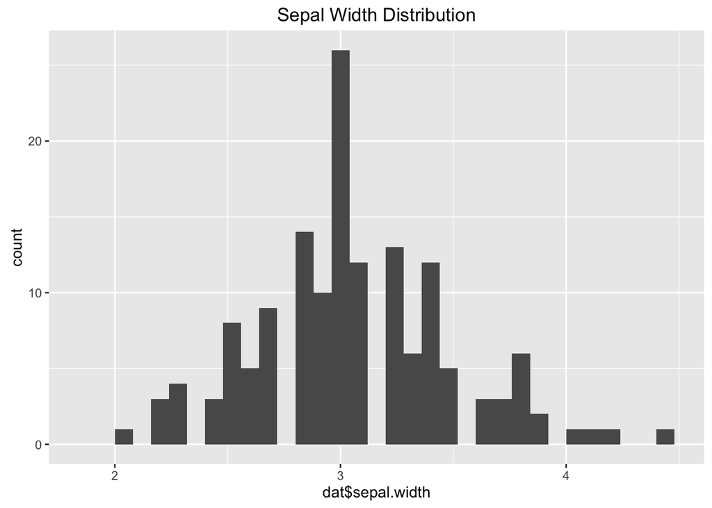

```r
qplot(x = dat$sepal.width,
      main = "Sepal Width Distribution")
```

## Explore Petal Properties

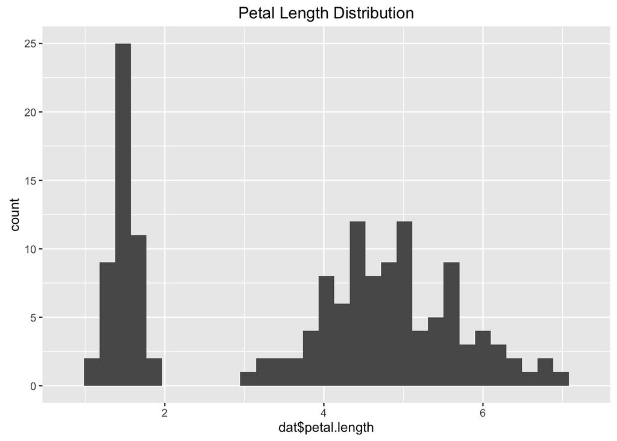

```r
qplot(x = dat$petal.length,
      main = "Petal Length Distribution")
```

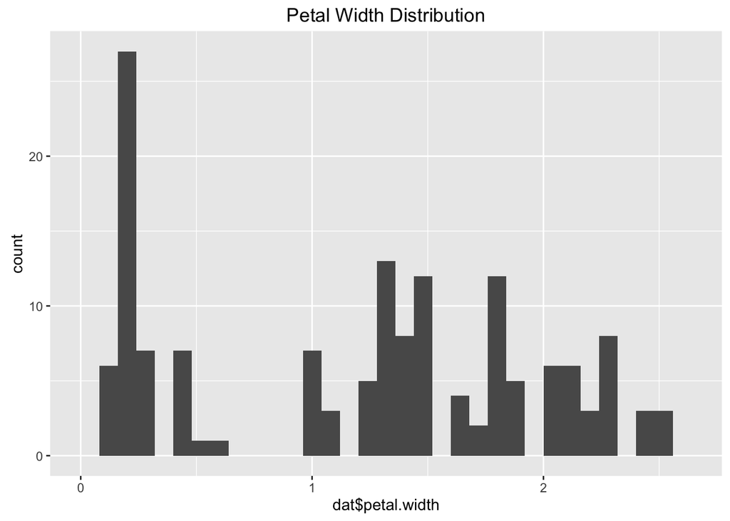

```r
qplot(x = dat$petal.width,
      main = "Petal Width Distribution")
```